# Capstone Final Report

Nick Glass

12/3/2021

# Overview:

The original goal of this project was to predict the amount of goals ECHL players create while they are on the ice. The idea was to capture their contribution by different aspects of the game such as 5 on 5 offense, 5 on 5 defense, power play, and penalty kill. The models would be broken up by forwards and defense, with the data providing game by game analysis for coaches to make decisions on player usage.

After complications with acquiring the data, time limitations, and not establishing a clear method to work with the coaching staff I decided to work with NHL seasonal data due to it being publicly available and easy to access. Furthermore, after realizing the amount of time this project would take and the fact that this would be my first major project I decided to only focus on 5 on 5 offense and 5 on 5 defense broken down by forwards and defensemen since this is the most common state of the game. Also, I decided to focus on only regression models to predict the amount of goals the players will score the next season not the amount of goals the player will create. For the models that predict how the player will prevent goals I decided to predict how many goals are scored against the players team when that player is on the ice. After making these changes my new goal for the project was to become more familiar with hockey analytics models and regression methods so I can build more complex models in the future.

# Load the data:

```r
# Load NHL individual stats 2013-14
## 2013-14 ##
IND_5V5_13_14 <- read_csv("Player_Season_Totals_13_14_IND_5V5.csv",
                          col_types = "cccciniiiiininniiiiiiiiiiiiiiiiiiin")
head(IND_5V5_13_14)
```

```
## # A tibble: 6 x 35
##   X1    Player Team  Position    GP   TOI Goals `Total Assists` `First Assists`
##   <chr> <chr>  <chr> <chr>    <int> <dbl> <int>           <int>           <int>
## 1 231   Ryan ~ ANA   C           77 1100.    23              36              21
## 2 237   Corey~ ANA   R           81 1159.    31              28              21
## 3 339   Sidne~ PIT   C           80 1272.    20              35              24
## 4 424   Phil ~ TOR   R           82 1341.    27              28              19
## 5 462   Jamie~ DAL   L           81 1104.    25              29              13
## 6 739   Taylo~ EDM   L           75 1139.    16              37              18
## # ... with 26 more variables: `Second Assists` <int>, `Total Points` <int>,
## #   IPP <dbl>, Shots <int>, `SH%` <dbl>, ixG <dbl>, iCF <int>, iFF <int>,
## #   iSCF <int>, iHDCF <int>, `Rush Attempts` <int>, `Rebounds Created` <int>,
## #   PIM <int>, `Total Penalties` <int>, Minor <int>, Major <int>,
## #   Misconduct <int>, `Penalties Drawn` <int>, Giveaways <int>,
## #   Takeaways <int>, Hits <int>, `Hits Taken` <int>, `Shots Blocked` <int>,
## #   `Faceoffs Won` <int>, `Faceoffs Lost` <int>, `Faceoffs %` <dbl>
```

```r
# Delete unnecessary columns
IND_5V5_13_14 <- IND_5V5_13_14[,-1]

# Load NHL on-ice stats 2013-14
OI_5V5_13_14 <- read_csv("Player_Season_Totals_13_14_OI_5V5.csv",
                         col_types = "cccciniiniiniiniinnnniiniiniiniiniiniiniinnnniiiiniiin")
head(OI_5V5_13_14)
```

```
## # A tibble: 6 x 54
##   X1    Player Team  Position    GP   TOI    CF    CA `CF%`    FF    FA `FF%`
##   <chr> <chr>  <chr> <chr>    <int> <dbl> <int> <int> <dbl> <int> <int> <dbl>
## 1 713   Greg ~ TOR   C            1  3.72     3     0 100       2     0 100
## 2 699   Bobby~ FLA   R            2 26.0     28    10  73.7    19    10  65.5
## 3 803   Ryan ~ DET   D            1 14.2     13     5  72.2    10     3  76.9
## 4 831   Karl ~ COL   D            2 12.9     11     5  68.8     9     4  69.2
## 5 761   Jason~ PHI   R            1 11.4     15     8  65.2    10     7  58.8
## 6 801   Xavie~ DET   D            4 52.1     50    27  64.9    40    22  64.5
## # ... with 42 more variables: SF <int>, SA <int>, `SF%` <dbl>, GF <int>,
## #   GA <int>, `GF%` <dbl>, xGF <dbl>, xGA <dbl>, `xGF%` <dbl>, SCF <int>,
## #   SCA <int>, `SCF%` <dbl>, HDCF <int>, HDCA <int>, `HDCF%` <dbl>, HDGF <int>,
## #   HDGA <int>, `HDGF%` <dbl>, MDCF <int>, MDCA <int>, `MDCF%` <dbl>,
## #   MDGF <int>, MDGA <int>, `MDGF%` <dbl>, LDCF <int>, LDCA <int>,
## #   `LDCF%` <dbl>, LDGF <int>, LDGA <int>, `LDGF%` <dbl>, `On-Ice SH%` <dbl>,
## #   `On-Ice SV%` <dbl>, PDO <dbl>, `Off. Zone Starts` <int>, `Neu. Zone
## #   Starts` <int>, `Def. Zone Starts` <int>, `On The Fly Starts` <int>,
## #   `Off. Zone Start %` <dbl>, `Off. Zone Faceoffs` <int>, `Neu. Zone
## #   Faceoffs` <int>, `Def. Zone Faceoffs` <int>, `Off. Zone Faceoff %` <dbl>
```

```r
# Delete unnecessary columns
OI_5V5_13_14 <- OI_5V5_13_14[, -c(1,3,4,5,6)]

# Join the two tables for 2013-14
Data_13_14 <- merge(x=IND_5V5_13_14,y=OI_5V5_13_14,by="Player",all=TRUE)
head(Data_13_14)
```

```
##           Player Team Position GP       TOI Goals Total Assists First Assists
## 1     Aaron Ness  NYI        D 20 264.70000     1             2             0
## 2 Aaron Palushaj  CAR        R  2  17.51667     0             0             0
## 3     Aaron Rome  DAL        D 25 297.28333     0             1             1
## 4 Aaron Volpatti  WSH        L 41 298.86667     2             0             0
## 5  Adam Almquist  DET        D  2  28.50000     1             0             0
## 6    Adam Burish  S.J        R 15 124.80000     0             0             0
##   Second Assists Total Points IPP Shots   SH%  ixG iCF iFF iSCF iHDCF
## 1              2            3 100    22  4.55 0.89  46  30   14     0
## 2              0            0  NA     2  0.00 0.18   4   4    1     1
## 3              0            1  10    14  0.00 0.48  35  21   10     1
## 4              0            2  50    18 11.11 2.05  39  27   21     9
## 5              0            1  50     2 50.00 0.18   3   2    2     1
## 6              0            0   0     9  0.00 0.80  18  16   10     5
##   Rush Attempts Rebounds Created PIM Total Penalties Minor Major Misconduct
```

[output cut: 55 more lines]

```r
## 2014-15 ##
# Load NHL individual stats 2014-15
IND_5V5_14_15 <- read_csv("Player_Season_Totals_14_15_IND_5V5.csv",
                          col_types = "cccciniiiiininniiiiiiiiiiiiiiiiiiin")

# Delete unnecessary columns
IND_5V5_14_15 <- IND_5V5_14_15[,-1]

# Load NHL on-ice stats 2014-15
OI_5V5_14_15 <- read_csv("Player_Season_Totals_14_15_OI_5V5.csv",
                         col_types = "cccciniiniiniiniinnnniiniiniiniiniiniiniinnnniiiiniiin")

# Delete unnecessary columns
OI_5V5_14_15 <- OI_5V5_14_15[, -c(1,3,4,5,6)]

# Join the two tables for 2014-15
Data_14_15 <- merge(x=IND_5V5_14_15,y=OI_5V5_14_15,by="Player",all=TRUE)

## 2015-16 ##
# Load NHL individual stats 2015-16
IND_5V5_15_16 <- read_csv("Player_Season_Totals_15_16_IND_5V5.csv",
                          col_types = "cccciniiiiininniiiiiiiiiiiiiiiiiiin")

# Delete unnecessary columns
IND_5V5_15_16 <- IND_5V5_15_16[,-1]

# Load NHL on-ice stats 2015-16
OI_5V5_15_16 <- read_csv("Player_Season_Totals_15_16_OI_5V5.csv",
                         col_types = "cccciniiniiniiniinnnniiniiniiniiniiniiniinnnniiiiniiin")

# Delete unnecessary columns
OI_5V5_15_16 <- OI_5V5_15_16[, -c(1,3,4,5,6)]

# Join the two tables for 2015-16
Data_15_16 <- merge(x=IND_5V5_15_16,y=OI_5V5_15_16,by="Player",all=TRUE)

## 2016-17 ##
# Load NHL individual stats for 2016-17
IND_5V5_16_17 <- read_csv("Player_Season_Totals_16_17_IND_5V5.csv",
                          col_types = "cccciniiiiininniiiiiiiiiiiiiiiiiiin")

# Delete unnecessary columns
IND_5V5_16_17 <- IND_5V5_16_17[,-1]

# Load NHL on-ice stats 2016-17
OI_5V5_16_17 <- read_csv("Player_Season_Totals_16_17_OI_5V5.csv",
                         col_types = "cccciniiniiniiniinnnniiniiniiniiniiniiniinnnniiiiniiin")

# Delete unnecessary columns
OI_5V5_16_17 <- OI_5V5_16_17[, -c(1,3,4,5,6)]

# Join the two tables for 2016-17
Data_16_17 <- merge(x=IND_5V5_16_17,y=OI_5V5_16_17,by="Player",all=TRUE)

## 2017-18 ##
# Load NHL individual stats 2017-18
IND_5V5_17_18 <- read_csv("Player_Season_Totals_17_18_IND_5V5.csv",
                          col_types = "cccciniiiiininniiiiiiiiiiiiiiiiiiin")

# Delete unnecessary columns
IND_5V5_17_18 <- IND_5V5_17_18[,-1]

# Load NHL on-ice stats 2017-18
OI_5V5_17_18 <- read_csv("Player_Season_Totals_17_18_OI_5V5.csv",
                         col_types = "cccciniiniiniiniinnnniiniiniiniiniiniiniinnnniiiiniiin")

# Delete unnecessary columns
OI_5V5_17_18 <- OI_5V5_17_18[, -c(1,3,4,5,6)]

# Join the two tables for 2017-18
Data_17_18 <- merge(x=IND_5V5_17_18,y=OI_5V5_17_18,by="Player",all=TRUE)

## 2018-19 ##
# Load NHL individual stats 2018-19
IND_5V5_18_19 <- read_csv("Player_Season_Totals_18_19_IND_5V5.csv",
                          col_types = "cccciniiiiininniiiiiiiiiiiiiiiiiiin")

# Delete unnecessary columns
IND_5V5_18_19 <- IND_5V5_18_19[,-1]

# Load NHL on-ice stats 2018-19
OI_5V5_18_19 <- read_csv("Player_Season_Totals_18_19_OI_5V5.csv",
                         col_types = "cccciniiniiniiniinnnniiniiniiniiniiniiniinnnniiiiniiin")

# Delete unnecessary columns
OI_5V5_18_19 <- OI_5V5_18_19[, -c(1,3,4,5,6)]

# Join the two tables for 2018-19
Data_18_19 <- merge(x=IND_5V5_18_19,y=OI_5V5_18_19,by="Player",all=TRUE)
```

# Analysis:

The data for this project is from Natural Stat Trick which is a hockey data website. The data selected is of NHL players from 2013-2019. Each year of data was loaded separately with two data files per season. One of the types of data includes individual statistics and the other includes counts of statistics while the player was on the ice. These data sets were merged together so there would be only one set of data per year.

# Create the response variables column:

```r
# Combine statistics with the next years actual goals
# Find the goals of 2014_15
goals14_15 <- Data_14_15 %>%
  dplyr::select(Player, Goals)

head(goals14_15)
```

```
##            Player Goals
## 1    Aaron Ekblad     6
## 2  Aaron Volpatti     0
## 3     Adam Burish     1
## 4 Adam Clendening     0
## 5  Adam Cracknell     0
## 6   Adam Henrique    10
```

```r
dim(goals14_15)
```

```
## [1] 882   2
```

```r
# Join goals14_15 with the 2013-14 data
clean_data13_14 <- inner_join(Data_13_14,
                              goals14_15,
                              by="Player")
head(clean_data13_14)
```

```
##           Player Team Position GP      TOI Goals.x Total Assists First Assists
## 1 Aaron Volpatti  WSH        L 41 298.8667       2             0             0
## 2    Adam Burish  S.J        R 15 124.8000       0             0             0
## 3 Adam Cracknell  STL        R 19 150.8500       0             2             1
## 4  Adam Henrique  N.J        C 77 994.9667      15             8             4
## 5   Adam Larsson  N.J        D 26 408.2333       1             2             2
## 6   Adam McQuaid  BOS        D 30 418.3833       1             5             2
##   Second Assists Total Points   IPP Shots   SH%  ixG iCF iFF iSCF iHDCF
## 1              0            2 50.00    18 11.11 2.05  39  27   21     9
## 2              0            0  0.00     9  0.00 0.80  18  16   10     5
## 3              1            2 33.33    16  0.00 1.21  28  23   13     7
## 4              4           23 67.65    92 16.30 9.82 156 124  110    57
## 5              0            3 30.00    19  5.26 0.56  50  30   11     0
## 6              3            6 30.00    25  4.00 0.51  56  31   10     1
##   Rush Attempts Rebounds Created PIM Total Penalties Minor Major Misconduct
```

[output cut: 55 more lines]

```r
# Find the goals of 2015_16
goals15_16 <- Data_15_16 %>%
  dplyr::select(Player, Goals)

# Join goals15_16 with the 2014-15 data
clean_data14_15 <- inner_join(Data_14_15,
                              goals15_16,
                              by="Player")

# Find the goals of 2016_17
goals16_17 <- Data_16_17 %>%
  dplyr::select(Player, Goals)

# Join goals16_17 with the 2015-16 data
clean_data15_16 <- inner_join(Data_15_16,
                              goals16_17,
                              by="Player")

# Find the goals of 2017_18
goals17_18 <- Data_17_18 %>%
  dplyr::select(Player, Goals)


# Join goals17_18 with the 2016-17 data
clean_data16_17 <- inner_join(Data_16_17,
                              goals17_18,
                              by="Player")

# Find the goals of 2018_19
goals18_19 <- Data_18_19 %>%
  dplyr::select(Player, Goals)

# Join goals18_19 with the 2017-18 data
clean_data17_18 <- inner_join(Data_17_18,
                              goals18_19,
                              by="Player")

# Combine the five seasons worth of data
hockey_data <- rbind(clean_data13_14, clean_data14_15, clean_data15_16,clean_data16_17, clean_data17_18)

head(hockey_data)
```

```
##           Player Team Position GP      TOI Goals.x Total Assists First Assists
## 1 Aaron Volpatti  WSH        L 41 298.8667       2             0             0
## 2    Adam Burish  S.J        R 15 124.8000       0             0             0
## 3 Adam Cracknell  STL        R 19 150.8500       0             2             1
## 4  Adam Henrique  N.J        C 77 994.9667      15             8             4
## 5   Adam Larsson  N.J        D 26 408.2333       1             2             2
## 6   Adam McQuaid  BOS        D 30 418.3833       1             5             2
##   Second Assists Total Points   IPP Shots   SH%  ixG iCF iFF iSCF iHDCF
## 1              0            2 50.00    18 11.11 2.05  39  27   21     9
## 2              0            0  0.00     9  0.00 0.80  18  16   10     5
## 3              1            2 33.33    16  0.00 1.21  28  23   13     7
## 4              4           23 67.65    92 16.30 9.82 156 124  110    57
## 5              0            3 30.00    19  5.26 0.56  50  30   11     0
## 6              3            6 30.00    25  4.00 0.51  56  31   10     1
##   Rush Attempts Rebounds Created PIM Total Penalties Minor Major Misconduct
```

[output cut: 55 more lines]

# Analysis:

For the models that predict a players offense the data was joined with the count of goals the players scored in the following year. This new column was named future goals and is the response variable for the offensive models. Each of the years were then combined to form a single new data frame that contains all of the necessary information called hockey_data. This data set includes 3646 observations or players and 83 columns or variables.

# Preparing the data for the forward offensive model:

```r
# Rename the Goals variables
hockey_data <- rename(hockey_data, Goals = Goals.x)
hockey_data <- rename(hockey_data, Future_Goals = Goals.y)
hockey_data <- rename(hockey_data, First_Assists = `First Assists`)
hockey_data <- rename(hockey_data, Second_Assists = `Second Assists`)
hockey_data <- rename(hockey_data, Rush_Attempts = `Rush Attempts`)
hockey_data <- rename(hockey_data, Rebounds_Created = `Rebounds Created`)
hockey_data <- rename(hockey_data, Off_Zone_Starts = `Off. Zone Starts`)
hockey_data <- rename(hockey_data, Neu_Zone_Starts = `Neu. Zone Starts`)
hockey_data <- rename(hockey_data, Def_Zone_Starts = `Def. Zone Starts`)
hockey_data <- rename(hockey_data, On_The_Fly_Starts = `On The Fly Starts`)

# Find the missing values by column
Missing_values <- sort(colSums(is.na(hockey_data)), decreasing = TRUE)
Missing_values <- Missing_values[Missing_values > 0]
print(sort(Missing_values), decreasing = TRUE)
```

```
##                SCF%          On-Ice SH% Off. Zone Faceoff %          On-Ice SV%
##                   1                   1                   1                   2
##               HDCF%               MDCF%   Off. Zone Start %                 SH%
##                   6                   6                   8                  55
##                 GF%               HDGF%                 IPP               MDGF%
##                  73                 122                 152                 225
##               LDGF%          Faceoffs %
##                 291                1366
```

```r
# Prepare the data for the forwards 5v5 offense model
Forward_Offense <- hockey_data %>%
  filter(Position == "R"|Position == "L"|Position == "C") %>%
  dplyr::select(Player:Rebounds_Created, Takeaways, On_The_Fly_Starts,                 Off_Zone_Starts:Def_Zone_Starts, Future_Goals)

# Insert zero for the missing IPP values
Forward_Offense$IPP[is.na(Forward_Offense$IPP)] = 0

# Find the dimensions of the data
dim(Forward_Offense)
```

```
## [1] 2291   26
```

```r
# Filtering for games played and teams played
Forward_Offense <- hockey_data %>%
  filter(Position == "R"|Position == "L"|Position == "C", GP > 10) %>%
  filter(str_detect(Team, pattern=",", negate=TRUE)) %>%
  dplyr::select(Player:Rebounds_Created, Takeaways, On_The_Fly_Starts,                 Off_Zone_Starts:Def_Zone_Starts, Future_Goals)

# Find the dimensions of the data after filtering by GP and Team
dim(Forward_Offense)
```

```
## [1] 1856   26
```

```r
# Add one goal to the future goals
Forward_Offense <- Forward_Offense %>%
  mutate(Future_Goals = Future_Goals + 1)

# Drop unwanted columns
Forward_Offense <- Forward_Offense[, -c(7,10,12,13,15)]
head(Forward_Offense)
```

```
##              Player Team Position GP      TOI Goals First_Assists
## 1    Aaron Volpatti  WSH        L 41 298.8667     2             0
## 2       Adam Burish  S.J        R 15 124.8000     0             0
## 3    Adam Cracknell  STL        R 19 150.8500     0             1
## 4     Adam Henrique  N.J        C 77 994.9667    15             4
## 5 Aleksander Barkov  FLA        C 54 722.1500     4            10
## 6     Alex Chiasson  DAL        R 79 846.7667     6             7
##   Second_Assists   IPP  ixG iFF iSCF iHDCF Rush_Attempts Rebounds_Created
## 1              0 50.00 2.05  27   21     9             1                5
## 2              0  0.00 0.80  16   10     5             1                0
## 3              1 33.33 1.21  23   13     7             0                1
## 4              4 67.65 9.82 124  110    57             5               13
## 5              3 54.84 5.55  78   64    26             2                9
## 6              7 64.52 9.10 126  111    49             8                8
##   Takeaways On_The_Fly_Starts Off_Zone_Starts Neu_Zone_Starts Def_Zone_Starts
## 1         6               220              55              93              34
## 2         2               111              22              29              18
## 3         3               146              23              35              10
## 4        36               747             171             235             126
## 5        25               535             126             176             114
## 6        22               698             173             213             111
##   Future_Goals
## 1            1
## 2            2
## 3            1
## 4           11
## 5           14
## 6            8
```

# Analysis:

Before the regression models could be made there needed to be some preprocessing. First, some variables were renamed to make them more convenient to work with. Second, the number of missing variables were identified and dealt with. For IPP which is the individual points percentage of the player, some values were NA when they should have been 0. In this case the value of 0 was imputed for the NA values. It turns out that all of the other variables that had missing values were not used anyway in the analysis. Third, the data set was filtered to only included centers, left wings, and right wings, otherwise known as forwards. The full data set for forwards includes 2291 observations or players and 26 columns or variables. In the subset of the data after filtering out players who played with more than one team in a season or played in less then 10 games, there is 1856 observations and 26 variables. After dropping unwanted variables the data set includes Player, Team, Position, GP, TOI, Goals, First Assists, Second Assists, IPP, ixG, iFF, iSCF, iHDCF, Rush_Attempts, Rebounds_Created, Takeaways, On_The_Fly_Starts, Neu_Zone_Starts, Def_Zone_Starts, and Future_Goals. Finally, one goal was added to the Future goals column in order to run the box cox transformation in the future.

# Creating the models to predict the forwards offense:

```r
# Regression analysis
# Splitting data into training and validation sets
set.seed(1)
train.rows.FO <- sample(rownames(Forward_Offense), nrow(Forward_Offense) * 0.7)
train.data.FO <- Forward_Offense[train.rows.FO, ]
valid.rows.FO <- setdiff(rownames(Forward_Offense), train.rows.FO)
valid.data.FO <- Forward_Offense[valid.rows.FO, ]

# Create a MLR model that contains the full desired predictors
FOM_Full <- lm(Future_Goals ~ Goals + First_Assists + Second_Assists +
                            + IPP + ixG + iFF + iSCF + iHDCF +
                            Rush_Attempts + Rebounds_Created +
                            Takeaways + On_The_Fly_Starts +
                            Off_Zone_Starts + Neu_Zone_Starts +
                            Def_Zone_Starts, data=train.data.FO)

# Summary
summary(FOM_Full)
```

```
##
## Call:
## lm(formula = Future_Goals ~ Goals + First_Assists + Second_Assists +
##     +IPP + ixG + iFF + iSCF + iHDCF + Rush_Attempts + Rebounds_Created +
##     Takeaways + On_The_Fly_Starts + Off_Zone_Starts + Neu_Zone_Starts +
##     Def_Zone_Starts, data = train.data.FO)
##
## Residuals:
##      Min       1Q   Median       3Q      Max
## -13.4718  -3.1859  -0.3623   2.7043  18.3949
##
## Coefficients:
##                     Estimate Std. Error t value Pr(>|t|)
## (Intercept)        5.1220660  0.7906715   6.478 1.32e-10 ***
## Goals              0.1964077  0.0429376   4.574 5.24e-06 ***
## First_Assists      0.0830886  0.0388572   2.138 0.032681 *
## Second_Assists     0.0749030  0.0520286   1.440 0.150211
## IPP               -0.0122983  0.0106307  -1.157 0.247542
## ixG               -0.1091105  0.2417024  -0.451 0.651760
## iFF               -0.0005709  0.0092930  -0.061 0.951026
## iSCF               0.0784618  0.0152979   5.129 3.36e-07 ***
## iHDCF             -0.0138401  0.0243129  -0.569 0.569287
## Rush_Attempts     -0.0380781  0.0498239  -0.764 0.444857
## Rebounds_Created   0.0364905  0.0383555   0.951 0.341593
## Takeaways          0.0675724  0.0141932   4.761 2.15e-06 ***
## On_The_Fly_Starts -0.0075397  0.0014403  -5.235 1.93e-07 ***
## Off_Zone_Starts    0.0150198  0.0045368   3.311 0.000957 ***
## Neu_Zone_Starts   -0.0113787  0.0045622  -2.494 0.012752 *
## Def_Zone_Starts   -0.0031718  0.0036677  -0.865 0.387311
## ---
## Signif. codes:  0 '***' 0.001 '**' 0.01 '*' 0.05 '.' 0.1 ' ' 1
##
## Residual standard error: 4.444 on 1280 degrees of freedom
##   (3 observations deleted due to missingness)
## Multiple R-squared:  0.4587, Adjusted R-squared:  0.4524
## F-statistic: 72.33 on 15 and 1280 DF,  p-value: < 2.2e-16
```

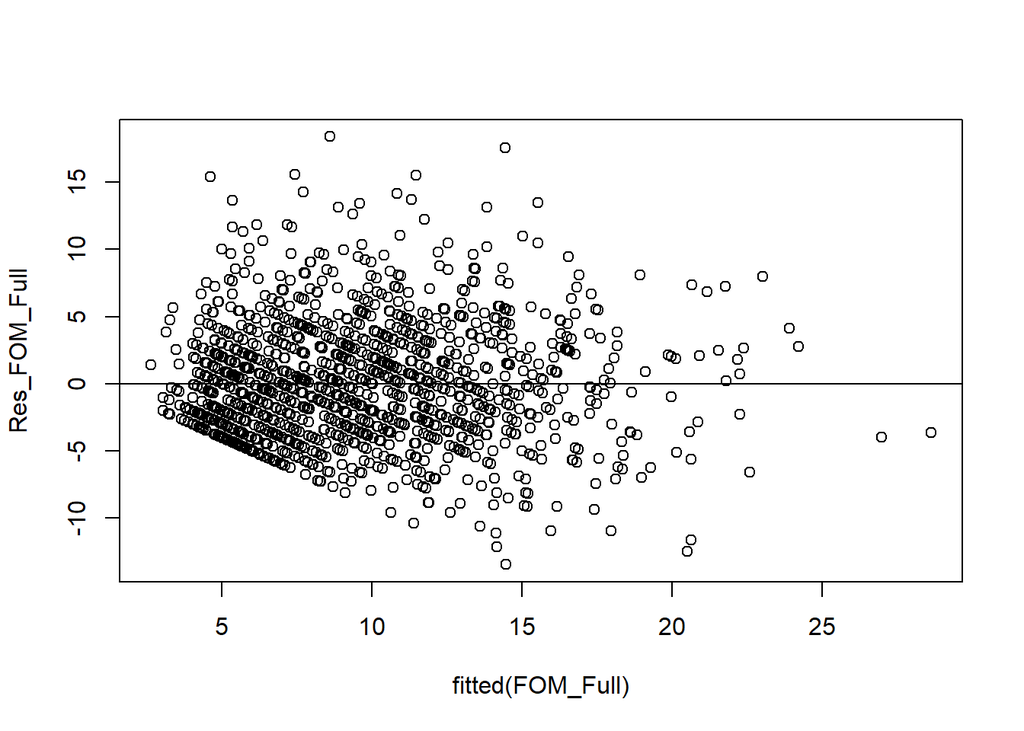

```r
# Get list of residuals
Res_FOM_Full <- resid(FOM_Full)

# Produce residual vs. fitted plot
plot(fitted(FOM_Full), Res_FOM_Full)

# Add a horizontal line at 0
abline(0,0)
```

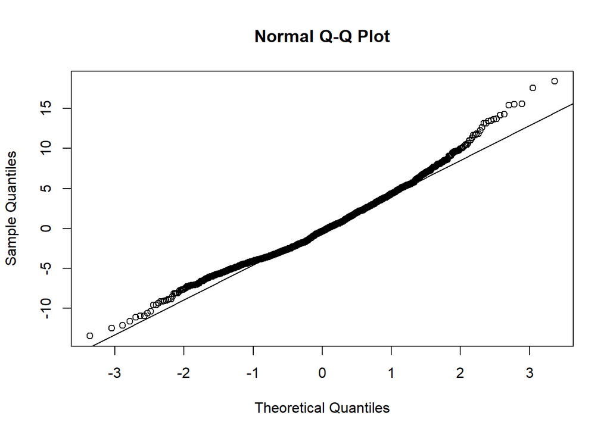

```r
# Create Q-Q plot for residuals
qqnorm(Res_FOM_Full)

# Add a straight diagonal line to the plot
qqline(Res_FOM_Full)
```

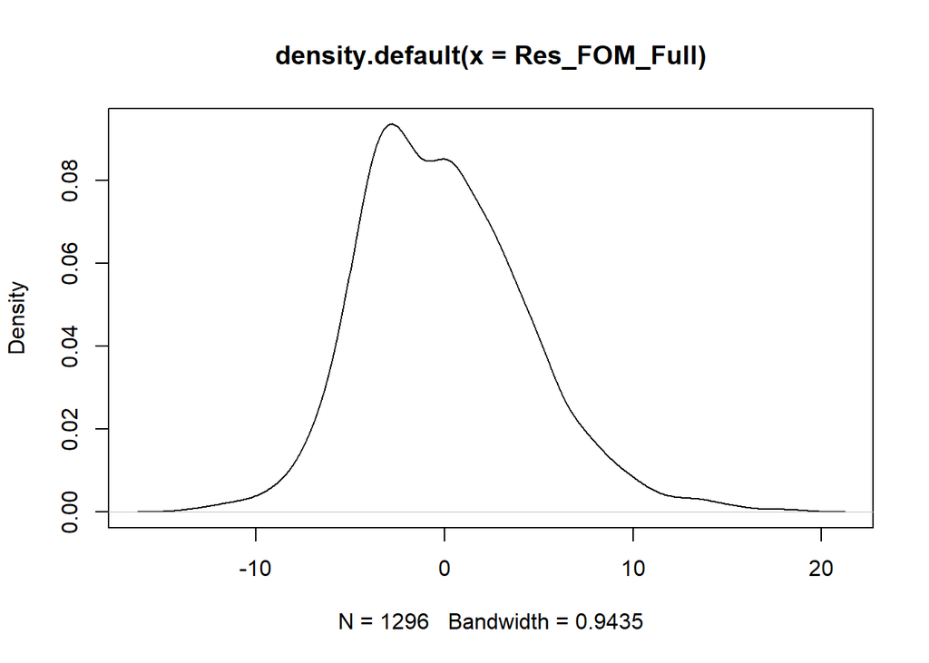

```r
# Create density plot of residuals
plot(density(Res_FOM_Full))
```

```r
# Calculate the error
accuracy(FOM_Full)
```

```
##                        ME     RMSE      MAE      MPE   MAPE      MASE
## Training set 2.609258e-16 4.416491 3.491824 -54.2431 78.378 0.7146159
```

```r
# Out-of-sample Prediction
pred_FOM_Full <- predict(FOM_Full, newdata=valid.data.FO)
pred_FOM_Full
```

[output not shown]

[output cut: 85 more lines]

[output not shown]

```r
# Find the error of the validation data
accuracy(pred_FOM_Full, valid.data.FO$Future_Goals)
```

```
##                   ME     RMSE      MAE       MPE     MAPE
## Test set -0.07265255 4.544833 3.517497 -57.45275 80.51285
```

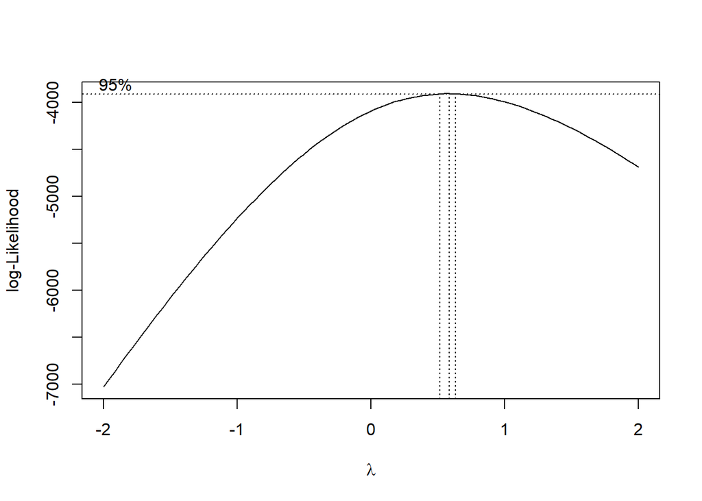

```r
# Applying Box-Cox transformation to lm object
bc.results=boxcox(FOM_Full) #Applying Box-Cox transformation to lm object
```

```r
lambda=bc.results$x[which.max(bc.results$y)] #extract the best lambda
lambda
```

```
## [1] 0.5858586
```

```r
lambda_FOM_Full <-lm(sqrt(Future_Goals) ~ Goals + First_Assists +
                      Second_Assists + IPP + ixG + iFF + iSCF + iHDCF +
                      Rush_Attempts + Rebounds_Created + Takeaways +
                      On_The_Fly_Starts + Off_Zone_Starts +
                      Neu_Zone_Starts +
                      Def_Zone_Starts,data=train.data.FO)

# Summary
summary(lambda_FOM_Full)
```

```
##
## Call:
## lm(formula = sqrt(Future_Goals) ~ Goals + First_Assists + Second_Assists +
##     IPP + ixG + iFF + iSCF + iHDCF + Rush_Attempts + Rebounds_Created +
##     Takeaways + On_The_Fly_Starts + Off_Zone_Starts + Neu_Zone_Starts +
##     Def_Zone_Starts, data = train.data.FO)
##
## Residuals:
##      Min       1Q   Median       3Q      Max
## -2.75689 -0.53866  0.02007  0.53288  2.49559
##
## Coefficients:
##                     Estimate Std. Error t value Pr(>|t|)
## (Intercept)        2.0497336  0.1371333  14.947  < 2e-16 ***
## Goals              0.0306745  0.0074471   4.119 4.05e-05 ***
## First_Assists      0.0141276  0.0067394   2.096 0.036253 *
## Second_Assists     0.0138197  0.0090238   1.531 0.125898
## IPP               -0.0020090  0.0018438  -1.090 0.276090
## ixG               -0.0211014  0.0419206  -0.503 0.614794
## iFF                0.0001746  0.0016118   0.108 0.913727
## iSCF               0.0113453  0.0026532   4.276 2.04e-05 ***
## iHDCF             -0.0005903  0.0042168  -0.140 0.888693
## Rush_Attempts     -0.0075757  0.0086414  -0.877 0.380829
## Rebounds_Created   0.0046190  0.0066523   0.694 0.487592
## Takeaways          0.0110045  0.0024617   4.470 8.50e-06 ***
## On_The_Fly_Starts -0.0011377  0.0002498  -4.554 5.76e-06 ***
## Off_Zone_Starts    0.0027154  0.0007869   3.451 0.000577 ***
## Neu_Zone_Starts   -0.0014867  0.0007913  -1.879 0.060488 .
## Def_Zone_Starts   -0.0000182  0.0006361  -0.029 0.977173
## ---
## Signif. codes:  0 '***' 0.001 '**' 0.01 '*' 0.05 '.' 0.1 ' ' 1
##
## Residual standard error: 0.7708 on 1280 degrees of freedom
##   (3 observations deleted due to missingness)
## Multiple R-squared:  0.4442, Adjusted R-squared:  0.4377
## F-statistic: 68.21 on 15 and 1280 DF,  p-value: < 2.2e-16
```

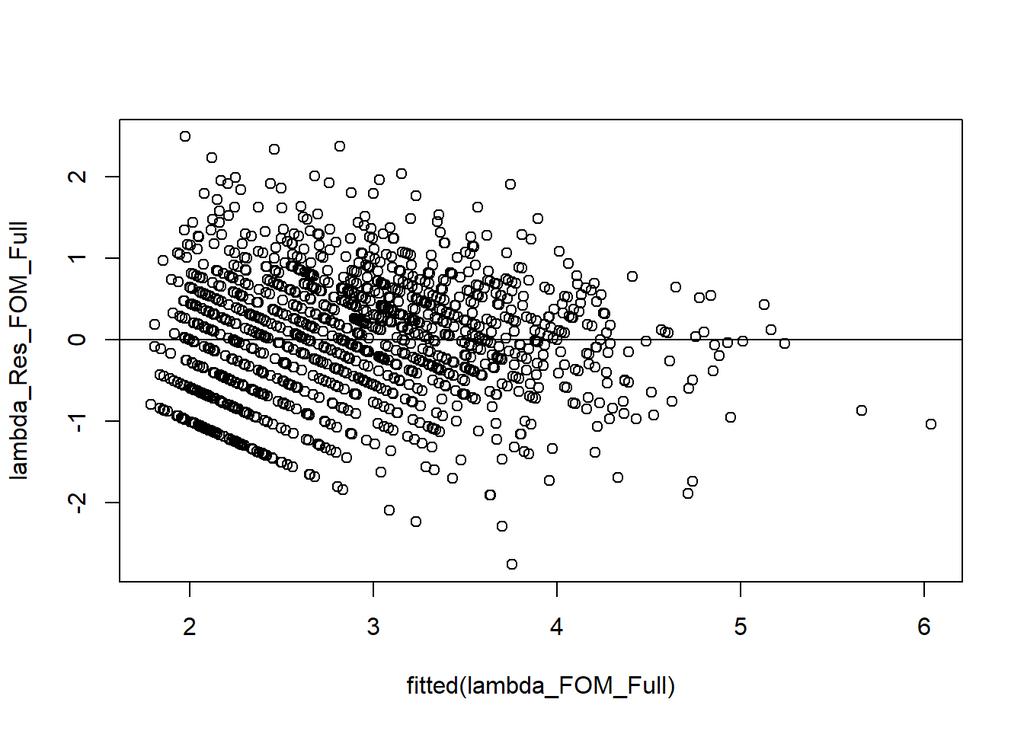

```r
# Get list of residuals
lambda_Res_FOM_Full <- resid(lambda_FOM_Full)

# Produce residual vs. fitted plot
plot(fitted(lambda_FOM_Full), lambda_Res_FOM_Full)

# Add a horizontal line at 0
abline(0,0)
```

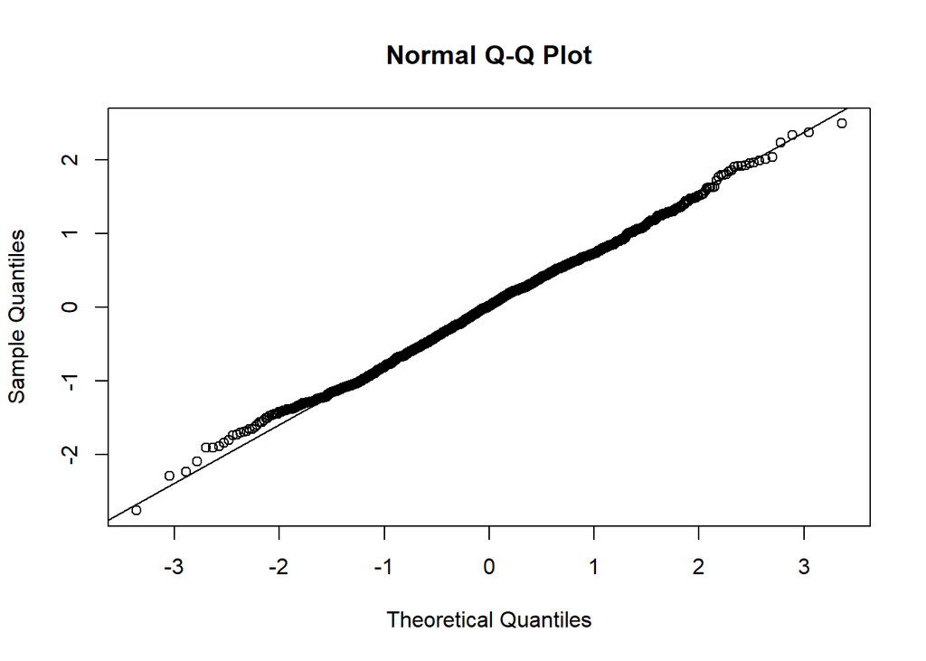

```r
# Create Q-Q plot for residuals
qqnorm(lambda_Res_FOM_Full)

# Add a straight diagonal line to the plot
qqline(lambda_Res_FOM_Full)
```

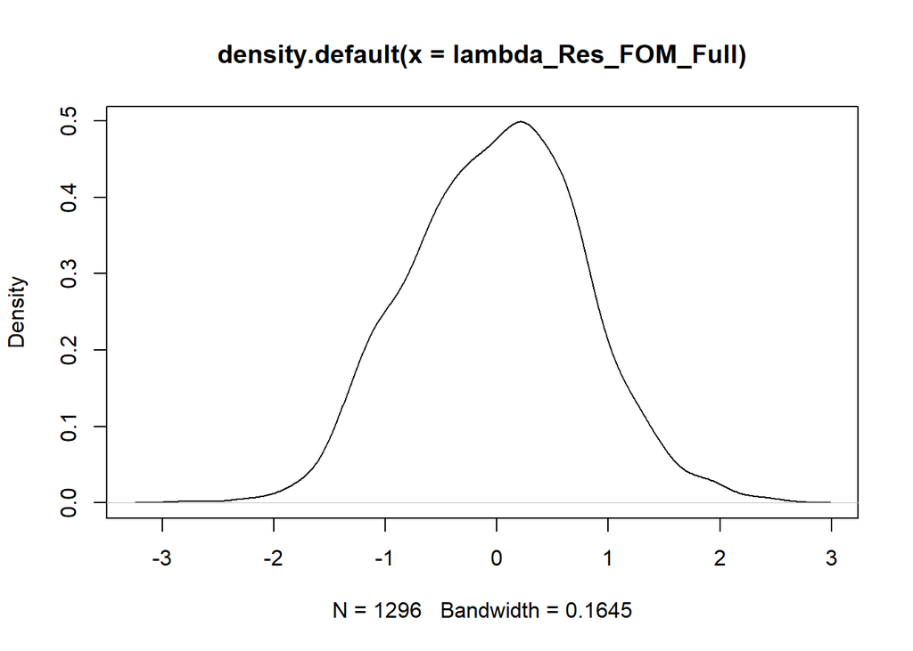

```r
# Create density plot of residuals
plot(density(lambda_Res_FOM_Full))
```

```r
# Compute VIF
vif(FOM_Full)
```

```
##             Goals     First_Assists    Second_Assists               IPP
##          4.028110          2.679554          2.201074          1.255287
##               ixG               iFF              iSCF             iHDCF
##         67.463199         23.443899         35.535994         19.061309
##     Rush_Attempts  Rebounds_Created         Takeaways On_The_Fly_Starts
##          2.308365          3.407005          2.631404          6.161910
##   Off_Zone_Starts   Neu_Zone_Starts   Def_Zone_Starts
##          6.086074          9.501865          2.978819
```

```r
# Compute VIF
vif(lambda_FOM_Full)
```

```
##             Goals     First_Assists    Second_Assists               IPP
##          4.028110          2.679554          2.201074          1.255287
##               ixG               iFF              iSCF             iHDCF
##         67.463199         23.443899         35.535994         19.061309
##     Rush_Attempts  Rebounds_Created         Takeaways On_The_Fly_Starts
##          2.308365          3.407005          2.631404          6.161910
##   Off_Zone_Starts   Neu_Zone_Starts   Def_Zone_Starts
##          6.086074          9.501865          2.978819
```

```r
# Calculate the error
accuracy(lambda_FOM_Full)
```

```
##                        ME      RMSE     MAE       MPE     MAPE      MASE
## Training set 1.839965e-17 0.7659919 0.61808 -11.24965 28.12588 0.7349305
```

```r
# Out-of-sample Prediction
pred_lambda_FOM_Full <- predict(lambda_FOM_Full, newdata=valid.data.FO)

# Undo the previous transformations
Real_pred_lambda_FOM_Full <- pred_lambda_FOM_Full^2 - 1
Real_pred_lambda_FOM_Full
```

[output not shown]

[output cut: 85 more lines]

[output not shown]

```r
# Find the error of the validation data
accuracy(Real_pred_lambda_FOM_Full, valid.data.FO$Future_Goals)
```

```
##                ME     RMSE      MAE       MPE     MAPE
## Test set 1.538656 4.823883 3.581841 -22.12531 60.75625
```

```r
# Best subset selection
best_subset_FOM=regsubsets(sqrt(Future_Goals) ~ Goals + First_Assists +
                           Second_Assists + IPP + ixG + iFF + iSCF +
                            iHDCF + Rush_Attempts + Rebounds_Created +
                            Takeaways + On_The_Fly_Starts +
                            Off_Zone_Starts + Neu_Zone_Starts +
                          Def_Zone_Starts, data=train.data.FO,nvmax=15)

# Summarize the result
best_summary_FOM=summary(best_subset_FOM)
best_summary_FOM
```

```
## Subset selection object
## Call: regsubsets.formula(sqrt(Future_Goals) ~ Goals + First_Assists +
##     Second_Assists + IPP + ixG + iFF + iSCF + iHDCF + Rush_Attempts +
##     Rebounds_Created + Takeaways + On_The_Fly_Starts + Off_Zone_Starts +
##     Neu_Zone_Starts + Def_Zone_Starts, data = train.data.FO,
##     nvmax = 15)
## 15 Variables  (and intercept)
##                   Forced in Forced out
## Goals                 FALSE      FALSE
## First_Assists         FALSE      FALSE
## Second_Assists        FALSE      FALSE
## IPP                   FALSE      FALSE
## ixG                   FALSE      FALSE
## iFF                   FALSE      FALSE
## iSCF                  FALSE      FALSE
## iHDCF                 FALSE      FALSE
## Rush_Attempts         FALSE      FALSE
## Rebounds_Created      FALSE      FALSE
## Takeaways             FALSE      FALSE
## On_The_Fly_Starts     FALSE      FALSE
## Off_Zone_Starts       FALSE      FALSE
## Neu_Zone_Starts       FALSE      FALSE
## Def_Zone_Starts       FALSE      FALSE
## 1 subsets of each size up to 15
## Selection Algorithm: exhaustive
##           Goals First_Assists Second_Assists IPP ixG iFF iSCF iHDCF
## 1  ( 1 )  " "   " "           " "            " " " " " " "*"  " "
## 2  ( 1 )  "*"   " "           " "            " " " " " " "*"  " "
## 3  ( 1 )  " "   " "           " "            " " " " " " "*"  " "
## 4  ( 1 )  "*"   " "           " "            " " " " " " "*"  " "
## 5  ( 1 )  "*"   " "           " "            " " " " " " "*"  " "
## 6  ( 1 )  "*"   "*"           " "            " " " " " " "*"  " "
## 7  ( 1 )  "*"   "*"           " "            " " " " " " "*"  " "
## 8  ( 1 )  "*"   "*"           "*"            " " " " " " "*"  " "
## 9  ( 1 )  "*"   "*"           "*"            "*" " " " " "*"  " "
## 10  ( 1 ) "*"   "*"           "*"            "*" " " " " "*"  " "
## 11  ( 1 ) "*"   "*"           "*"            "*" " " " " "*"  "*"
## 12  ( 1 ) "*"   "*"           "*"            "*" "*" " " "*"  " "
## 13  ( 1 ) "*"   "*"           "*"            "*" "*" " " "*"  "*"
## 14  ( 1 ) "*"   "*"           "*"            "*" "*" "*" "*"  "*"
```

[output cut: 18 more lines]

```
## 1  ( 1 )  " "             " "             " "
## 2  ( 1 )  " "             " "             " "
## 3  ( 1 )  " "             " "             " "
## 4  ( 1 )  " "             " "             " "
## 5  ( 1 )  "*"             " "             " "
## 6  ( 1 )  "*"             " "             " "
## 7  ( 1 )  "*"             "*"             " "
## 8  ( 1 )  "*"             "*"             " "
## 9  ( 1 )  "*"             "*"             " "
## 10  ( 1 ) "*"             "*"             " "
## 11  ( 1 ) "*"             "*"             " "
## 12  ( 1 ) "*"             "*"             " "
## 13  ( 1 ) "*"             "*"             " "
## 14  ( 1 ) "*"             "*"             " "
## 15  ( 1 ) "*"             "*"             "*"
```

```r
# Find the best Cp
p=2:16
Cp=cbind(p,best_summary_FOM$cp) #Pair p and Cp
colnames(Cp)=c('p','Cp') #Define column names
print(Cp)
```

```
##        p        Cp
##  [1,]  2 99.379241
##  [2,]  3 68.383402
##  [3,]  4 44.973861
##  [4,]  5 24.273090
##  [5,]  6 10.024079
##  [6,]  7  7.489033
##  [7,]  8  4.951250
##  [8,]  9  4.854518
##  [9,] 10  5.622517
## [10,] 11  7.034031
## [11,] 12  8.604594
## [12,] 13 10.063889
## [13,] 14 12.012381
## [14,] 15 14.000819
## [15,] 16 16.000000
```

```r
# Find BIC
p=2:16
BIC=cbind(p,best_summary_FOM$bic) #Pair p and BIC
colnames(BIC)=c('p','BIC') #Define column names
print(BIC)
```

```
##        p       BIC
##  [1,]  2 -638.7986
##  [2,]  3 -662.7359
##  [3,]  4 -680.0410
##  [4,]  5 -695.1352
##  [5,]  6 -704.1407
##  [6,]  7 -701.5236
##  [7,]  8 -698.9253
##  [8,]  9 -693.8747
##  [9,] 10 -687.9529
## [10,] 11 -681.3811
## [11,] 12 -674.6486
## [12,] 13 -668.0289
## [13,] 14 -660.9140
## [14,] 15 -653.7586
## [15,] 16 -646.5924
```

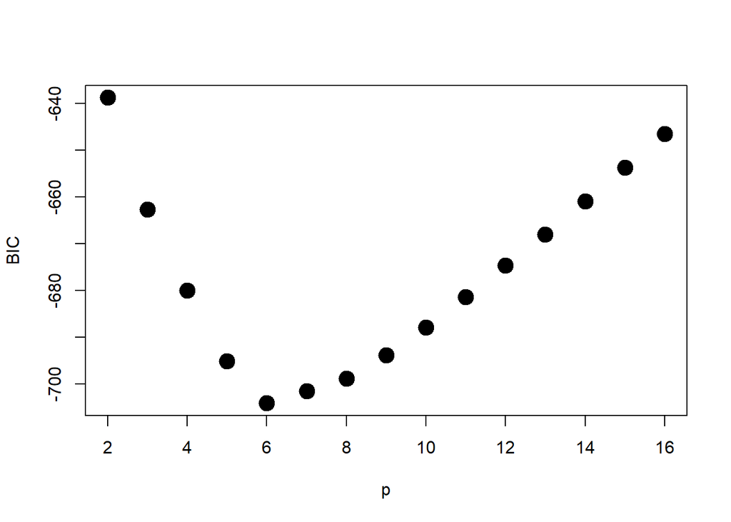

```r
plot(BIC,cex=2,pch=19) # Plot of BIC
```

```r
# Find AIC
n=nrow(train.data.FO)
p=BIC[,1]
aic=BIC[,2]-p*log(n)+2*p #Need to compute AIC using BIC
AIC=cbind(2:16,aic) #Pair p and AIC
colnames(AIC)=c('p','AIC') #Define column names
print(AIC)
```

```
##        p       AIC
##  [1,]  2 -649.1373
##  [2,]  3 -678.2439
##  [3,]  4 -700.7184
##  [4,]  5 -720.9820
##  [5,]  6 -735.1568
##  [6,]  7 -737.7090
##  [7,]  8 -740.2801
##  [8,]  9 -740.3989
##  [9,] 10 -739.6464
## [10,] 11 -738.2439
## [11,] 12 -736.6808
## [12,] 13 -735.2304
## [13,] 14 -733.2849
## [14,] 15 -731.2989
## [15,] 16 -729.3020
```

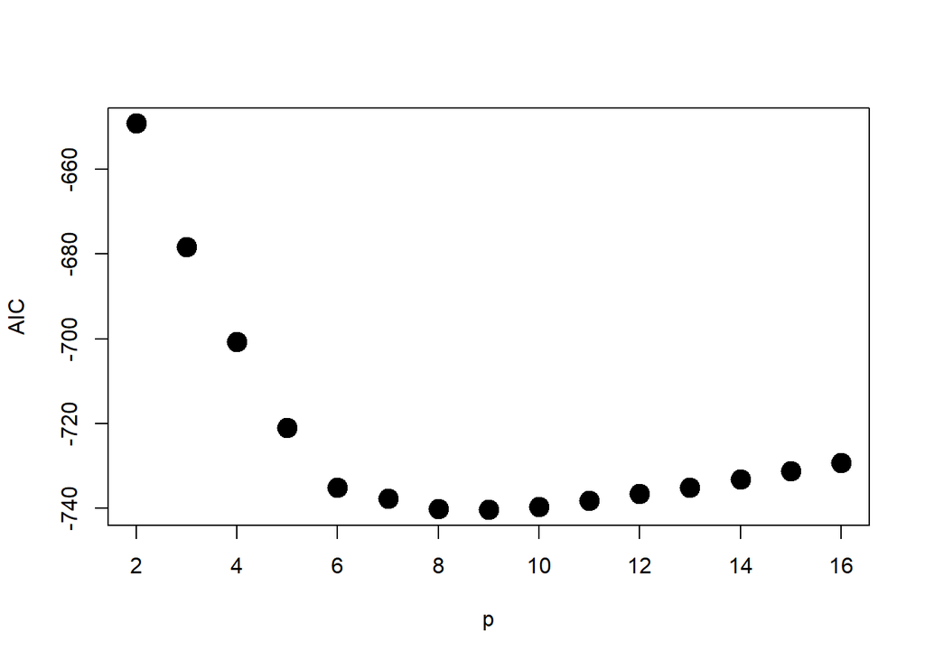

```r
plot(AIC,cex=2,pch=19) #Plot of AIC
```

```r
# Best Cp Model
FOM_BestCp <- lm(sqrt(Future_Goals) ~ Goals + First_Assists + iSCF +
                   Takeaways + On_The_Fly_Starts + Off_Zone_Starts +
                   Neu_Zone_Starts,data=train.data.FO)
# Summary
summary(FOM_BestCp)
```

```
##
## Call:
## lm(formula = sqrt(Future_Goals) ~ Goals + First_Assists + iSCF +
##     Takeaways + On_The_Fly_Starts + Off_Zone_Starts + Neu_Zone_Starts,
##     data = train.data.FO)
##
## Residuals:
##      Min       1Q   Median       3Q      Max
## -2.76915 -0.54348  0.02637  0.54317  2.44085
##
## Coefficients:
##                     Estimate Std. Error t value Pr(>|t|)
## (Intercept)        1.8948993  0.0642897  29.474  < 2e-16 ***
## Goals              0.0278050  0.0070637   3.936 8.72e-05 ***
## First_Assists      0.0150399  0.0064137   2.345   0.0192 *
## iSCF               0.0097495  0.0010831   9.002  < 2e-16 ***
## Takeaways          0.0113275  0.0024003   4.719 2.63e-06 ***
## On_The_Fly_Starts -0.0011070  0.0002429  -4.557 5.68e-06 ***
## Off_Zone_Starts    0.0029401  0.0007469   3.936 8.72e-05 ***
## Neu_Zone_Starts   -0.0013871  0.0006568  -2.112   0.0349 *
## ---
## Signif. codes:  0 '***' 0.001 '**' 0.01 '*' 0.05 '.' 0.1 ' ' 1
##
## Residual standard error: 0.77 on 1291 degrees of freedom
## Multiple R-squared:  0.4442, Adjusted R-squared:  0.4411
## F-statistic: 147.4 on 7 and 1291 DF,  p-value: < 2.2e-16
```

```r
# Compute VIF
vif(FOM_BestCp)
```

```
##             Goals     First_Assists              iSCF         Takeaways
##          3.650901          2.441881          5.970175          2.519870
## On_The_Fly_Starts   Off_Zone_Starts   Neu_Zone_Starts
##          5.903288          5.536143          6.620445
```

```r
# Calculate the error
accuracy(FOM_BestCp)
```

```
##                         ME     RMSE      MAE       MPE     MAPE      MASE
## Training set -5.968954e-18 0.767602 0.619376 -11.32479 28.24402 0.7346926
```

```r
# Out-of-sample Prediction
pred_FOM_BestCp <- predict(FOM_BestCp, newdata=valid.data.FO)

# Undo the previous transformations
Real_pred_FOM_BestCp <- pred_FOM_BestCp^2 - 1
Real_pred_FOM_BestCp
```

[output not shown]

[output cut: 85 more lines]

[output not shown]

```r
# Find the error of the validation data
accuracy(Real_pred_FOM_BestCp, valid.data.FO$Future_Goals)
```

```
##                ME    RMSE      MAE       MPE     MAPE
## Test set 1.530981 4.80589 3.567284 -21.58011 60.16228
```

```r
# Best BIC Model
FOM_BestBIC <- lm(sqrt(Future_Goals) ~ Goals + iSCF + Takeaways +
                    On_The_Fly_Starts +
                    Off_Zone_Starts,data=train.data.FO)
# Summary
summary(FOM_BestBIC)
```

```
##
## Call:
## lm(formula = sqrt(Future_Goals) ~ Goals + iSCF + Takeaways +
##     On_The_Fly_Starts + Off_Zone_Starts, data = train.data.FO)
##
## Residuals:
##      Min       1Q   Median       3Q      Max
## -2.89330 -0.55716  0.02077  0.53695  2.49807
##
## Coefficients:
##                     Estimate Std. Error t value Pr(>|t|)
## (Intercept)        1.8774821  0.0640136  29.329  < 2e-16 ***
## Goals              0.0295985  0.0070396   4.205 2.80e-05 ***
## iSCF               0.0094470  0.0010664   8.859  < 2e-16 ***
## Takeaways          0.0124532  0.0023318   5.341 1.09e-07 ***
## On_The_Fly_Starts -0.0013422  0.0002102  -6.385 2.39e-10 ***
## Off_Zone_Starts    0.0028169  0.0006997   4.026 6.01e-05 ***
## ---
## Signif. codes:  0 '***' 0.001 '**' 0.01 '*' 0.05 '.' 0.1 ' ' 1
##
## Residual standard error: 0.7721 on 1293 degrees of freedom
## Multiple R-squared:  0.4403, Adjusted R-squared:  0.4381
## F-statistic: 203.4 on 5 and 1293 DF,  p-value: < 2.2e-16
```

```r
# Compute VIF
vif(FOM_BestBIC)
```

```
##             Goals              iSCF         Takeaways On_The_Fly_Starts
##          3.606518          5.756627          2.365181          4.397370
##   Off_Zone_Starts
##          4.832537
```

```r
# Calculate the error
accuracy(FOM_BestBIC)
```

```
##                       ME      RMSE       MAE      MPE     MAPE      MASE
## Training set 9.90046e-18 0.7702685 0.6226217 -11.3569 28.34218 0.7385427
```

```r
# Out-of-sample Prediction
pred_FOM_BestBIC <- predict(FOM_BestBIC, newdata = valid.data.FO)

# Undo the previous transformations
Real_pred_FOM_BestBIC <- pred_FOM_BestBIC^2 - 1
Real_pred_FOM_BestBIC
```

[output not shown]

[output cut: 85 more lines]

[output not shown]

```r
# Find the error of the validation data
accuracy(Real_pred_FOM_BestBIC, valid.data.FO$Future_Goals)
```

```
##                ME     RMSE      MAE       MPE     MAPE
## Test set 1.512713 4.802105 3.547997 -21.64733 59.77868
```

```r
# Best AIC Model
FOM_BestAIC <- lm(sqrt(Future_Goals) ~ Goals + First_Assists + iSCF +
                    Takeaways + On_The_Fly_Starts + Off_Zone_Starts +
                    Neu_Zone_Starts,data=train.data.FO)
# Summary
summary(FOM_BestAIC)
```

```
##
## Call:
## lm(formula = sqrt(Future_Goals) ~ Goals + First_Assists + iSCF +
##     Takeaways + On_The_Fly_Starts + Off_Zone_Starts + Neu_Zone_Starts,
##     data = train.data.FO)
##
## Residuals:
##      Min       1Q   Median       3Q      Max
## -2.76915 -0.54348  0.02637  0.54317  2.44085
##
## Coefficients:
##                     Estimate Std. Error t value Pr(>|t|)
## (Intercept)        1.8948993  0.0642897  29.474  < 2e-16 ***
## Goals              0.0278050  0.0070637   3.936 8.72e-05 ***
## First_Assists      0.0150399  0.0064137   2.345   0.0192 *
## iSCF               0.0097495  0.0010831   9.002  < 2e-16 ***
## Takeaways          0.0113275  0.0024003   4.719 2.63e-06 ***
## On_The_Fly_Starts -0.0011070  0.0002429  -4.557 5.68e-06 ***
## Off_Zone_Starts    0.0029401  0.0007469   3.936 8.72e-05 ***
## Neu_Zone_Starts   -0.0013871  0.0006568  -2.112   0.0349 *
## ---
## Signif. codes:  0 '***' 0.001 '**' 0.01 '*' 0.05 '.' 0.1 ' ' 1
##
## Residual standard error: 0.77 on 1291 degrees of freedom
## Multiple R-squared:  0.4442, Adjusted R-squared:  0.4411
## F-statistic: 147.4 on 7 and 1291 DF,  p-value: < 2.2e-16
```

```r
# Compute VIF
vif(FOM_BestAIC)
```

```
##             Goals     First_Assists              iSCF         Takeaways
##          3.650901          2.441881          5.970175          2.519870
## On_The_Fly_Starts   Off_Zone_Starts   Neu_Zone_Starts
##          5.903288          5.536143          6.620445
```

```r
# Calculate the error
accuracy(FOM_BestAIC)
```

```
##                         ME     RMSE      MAE       MPE     MAPE      MASE
## Training set -5.968954e-18 0.767602 0.619376 -11.32479 28.24402 0.7346926
```

```r
# Out-of-sample Prediction
pred_FOM_BestAIC <- predict(FOM_BestAIC, newdata = valid.data.FO)

# Undo the previous transformations
Real_pred_FOM_BestAIC <- pred_FOM_BestAIC^2 - 1
Real_pred_FOM_BestAIC
```

[output not shown]

[output cut: 85 more lines]

[output not shown]

```r
# Find the error of the validation data
accuracy(Real_pred_FOM_BestAIC, valid.data.FO$Future_Goals)
```

```
##                ME    RMSE      MAE       MPE     MAPE
## Test set 1.530981 4.80589 3.567284 -21.58011 60.16228
```

# Analysis:

# Picking the model:

[figure not shown]

```r
# Error table
knitr::include_graphics("C:/Users/nickg/OneDrive/Desktop/Capstone/FOM_Error_Table.png")
```

# Analysis:

For the forward offensive model it was tough to chose between the AIC/Cp model and the BIC but I decided to chose the BIC model as the best for a few reasons. First, both the RMSE and the MAE were the lowest even if they were close. Second, I know the BIC model had the lower of the adjusted r-square values but it is close enough to not make a huge difference. The deciding factor for me was that the BIC model is the simplest of the three. The predictors used for this model are Goals, iSCF, Takeaways, On_The_Fly_Starts, and Off_Zone_Starts. Each of these variables makes sense in a logical sense. I expected the number of goals, scoring chances, takeaways, and offensive zone starts to lead to future goals. I find it interesting that as the number of on the fly starts increases we expect the number of future goals to decrease. I feel this model does a good job predicting future goals without having extra variables like the AIC or Cp. This makes a difference when explaining and using the model in a practical setting like a hockey teams front office.

# Preparing the data for the defense offensive model:

# Analysis:

The same process was used in the preprocessing for the defense offensive model as the forward offensive model with the exception that I filtered for defensemen instead of forwards. In this data set there are 1047 observations. Refer to the original steps for the process if needed.

# Creating the models to predict defensmen’s offense:

```r
# Regression analysis
# Splitting data into training and validation sets
set.seed(1)
train.rows.DO <- sample(rownames(Defense_Offensive), nrow(Defense_Offensive) * 0.7)
train.data.DO <- Defense_Offensive[train.rows.DO, ]
valid.rows.DO <- setdiff(rownames(Defense_Offensive), train.rows.DO)
valid.data.DO <- Defense_Offensive[valid.rows.DO, ]

# Create a MLR model that contains the full desired predictors
DOM_Full <- lm(Future_Goals ~ Goals + First_Assists + Second_Assists
               + IPP + ixG + iFF + iSCF + iHDCF + Rush_Attempts
               + Rebounds_Created + Takeaways + On_The_Fly_Starts +
                 Off_Zone_Starts + Neu_Zone_Starts
               + Def_Zone_Starts, data = train.data.DO)
# Summary
summary(DOM_Full)
```

```
##
## Call:
## lm(formula = Future_Goals ~ Goals + First_Assists + Second_Assists +
##     IPP + ixG + iFF + iSCF + iHDCF + Rush_Attempts + Rebounds_Created +
##     Takeaways + On_The_Fly_Starts + Off_Zone_Starts + Neu_Zone_Starts +
##     Def_Zone_Starts, data = train.data.DO)
##
## Residuals:
##     Min      1Q  Median      3Q     Max
## -5.0336 -1.3686 -0.3138  1.0489 12.8534
##
## Coefficients:
##                     Estimate Std. Error t value Pr(>|t|)
## (Intercept)        1.7627585  0.4093461   4.306 1.89e-05 ***
## Goals              0.1357222  0.0505540   2.685  0.00743 **
## First_Assists      0.0161802  0.0401963   0.403  0.68741
## Second_Assists    -0.0232732  0.0377365  -0.617  0.53761
## IPP               -0.0002953  0.0109910  -0.027  0.97857
## ixG                0.8415418  0.2758370   3.051  0.00237 **
## iFF                0.0037101  0.0063353   0.586  0.55831
## iSCF               0.0189405  0.0140244   1.351  0.17727
## iHDCF             -0.0818726  0.0389295  -2.103  0.03581 *
## Rush_Attempts     -0.0846687  0.0496957  -1.704  0.08886 .
## Rebounds_Created  -0.0031347  0.0285824  -0.110  0.91270
## Takeaways         -0.0018773  0.0110139  -0.170  0.86471
## On_The_Fly_Starts -0.0026768  0.0006798  -3.938 9.04e-05 ***
## Off_Zone_Starts    0.0029954  0.0030905   0.969  0.33275
## Neu_Zone_Starts    0.0054775  0.0030107   1.819  0.06928 .
## Def_Zone_Starts   -0.0039062  0.0035949  -1.087  0.27758
## ---
## Signif. codes:  0 '***' 0.001 '**' 0.01 '*' 0.05 '.' 0.1 ' ' 1
##
## Residual standard error: 2.219 on 715 degrees of freedom
##   (1 observation deleted due to missingness)
## Multiple R-squared:  0.3488, Adjusted R-squared:  0.3352
## F-statistic: 25.53 on 15 and 715 DF,  p-value: < 2.2e-16
```

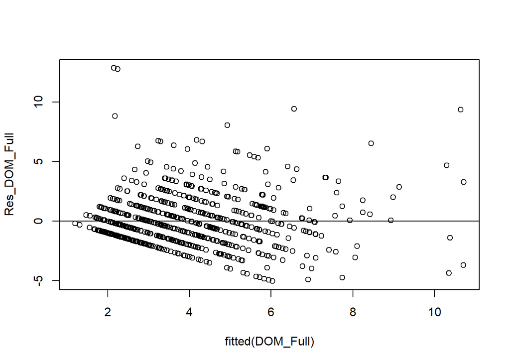

```r
# Get list of residuals
Res_DOM_Full <- resid(DOM_Full)

# Produce residual vs. fitted plot
plot(fitted(DOM_Full), Res_DOM_Full)

# Add a horizontal line at 0
abline(0,0)
```

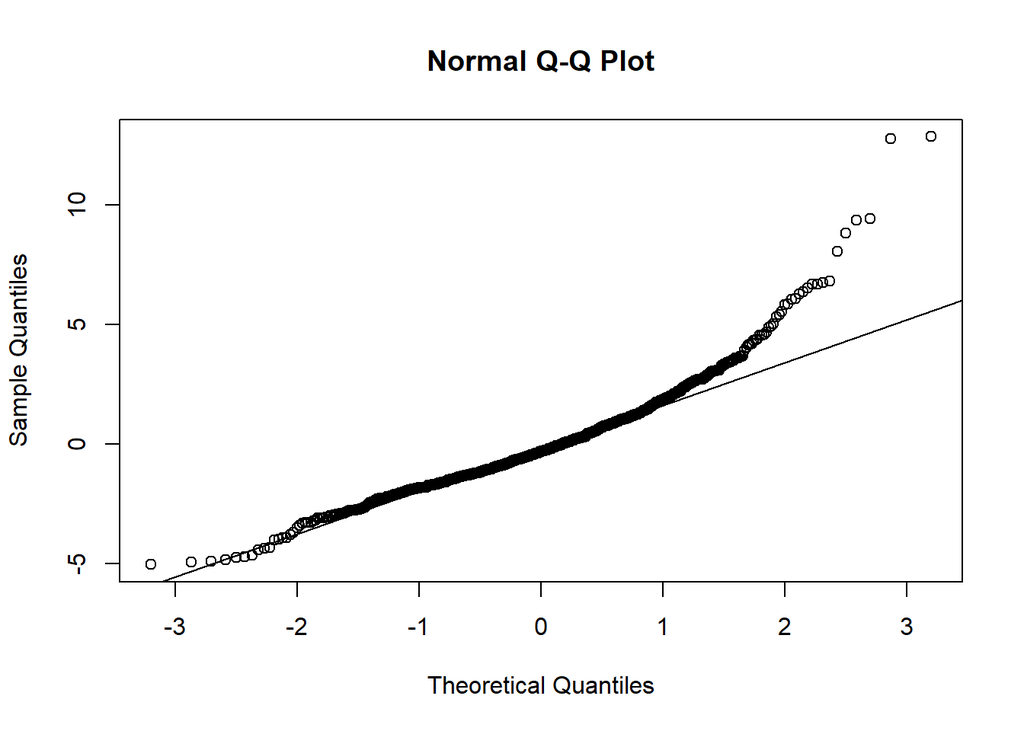

```r
# Create Q-Q plot for residuals
qqnorm(Res_DOM_Full)

# Add a straight diagonal line to the plot
qqline(Res_DOM_Full)
```

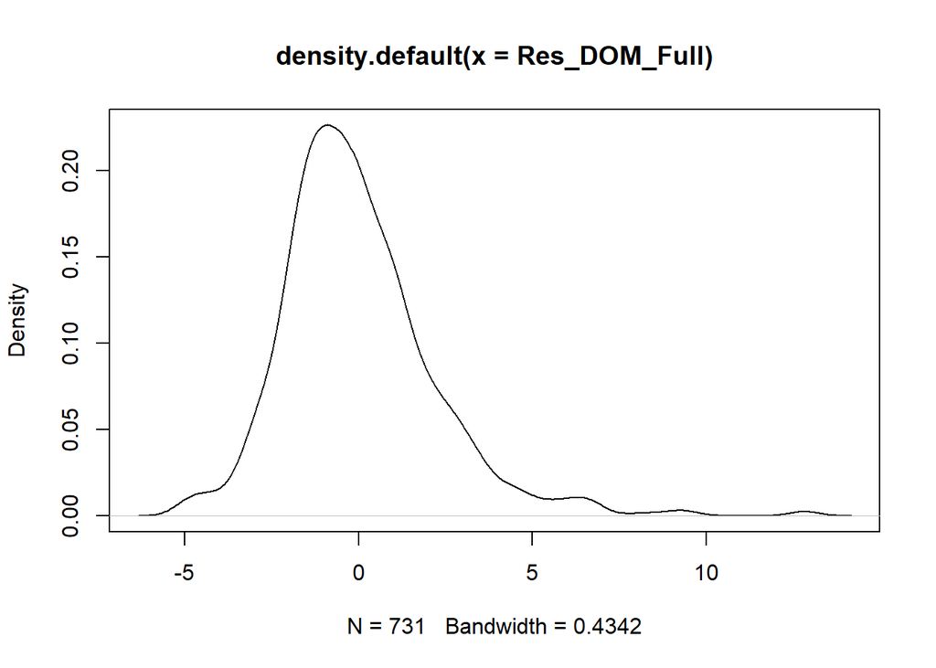

```r
# Create density plot of residuals
plot(density(Res_DOM_Full))
```

```r
# Calculate the error
accuracy(DOM_Full)
```

```
##                         ME     RMSE      MAE      MPE     MAPE      MASE
## Training set -4.729222e-16 2.194941 1.611164 -39.6914 63.70345 0.7756537
```

```r
# Out-of-sample Prediction
pred_DOM_Full <- predict(DOM_Full, newdata=valid.data.DO)
pred_DOM_Full
```

```
##         2         4        10        18        21        23        24        26
##  2.004357  5.152859  4.043118  4.694152  5.294843  4.249642 14.546324  2.599708
##        32        34        38        46        47        50        53        57
##  2.245558  3.445764  3.053623  2.257506  1.842911  3.953646  3.037110  3.843188
##        59        63        64        68        74        75        76        78
##  3.820367  9.043268  3.106370  4.043242  2.463897  4.128111  2.680836  4.826762
##        88        90        94        95        96        98       106       107
##  1.834740  4.006633  4.926307  5.679203  4.470003  2.951002  1.798170  4.705122
##       113       114       120       123       125       131       134       136
##  6.065135  2.196890  3.741297  2.623672  5.884080  1.972814  6.112454  3.912638
##       142       144       147       149       151       152       154       155
##  1.964679  4.072733  4.455851  6.651972  3.886711  2.107787  2.798764  1.898227
##       156       157       160       163       165       170       171       172
##  3.689438  4.622232  4.290709  4.757425  3.846209  4.283766  2.344548  1.701999
##       174       178       186       187       188       189       191       195
##  2.506547  3.323529  2.960944  3.531967  2.875962  1.975118  2.413905  5.050879
##       196       199       202       203       204       210       212       216
##  4.143240  5.088754  1.807358  4.169391  1.660491  3.541559  5.601979  4.367917
##       221       223       224       227       228       230       231       237
##  2.679340  1.334929  4.949359  2.627708  2.472106  6.368278  3.128347  2.012502
##       238       239       240       244       246       249       253       254
##  2.892094  3.213264  7.679742  2.267704  3.194812  2.826274  3.459520  4.153187
##       255       259       263       265       267       269       272       274
##  2.234730  4.486986  3.701546  3.432748  2.586712  4.410010  7.946833  8.858316
##       275       289       292       297       298       301       307       311
##  2.502070  3.432382  2.212752  2.353004  3.622914  4.755396  1.661825  5.982235
##       314       317       318       319       321       331       332       333
##  2.613960  5.034588  1.864640  6.451883  4.228564  1.496393  2.414058  4.865249
##       337       344       347       350       364       366       370       372
##  3.381352  2.582149  5.315133  6.113163  2.141022  3.338210  3.645416  2.008896
##       373       376       379       385       387       389       394       395
##  3.519116  3.700422  7.665245  1.814232  5.111329  1.858850  3.840375  3.205510
##       398       400       401       405       410       411       416       417
##  5.498590  2.326236  5.026047  3.848691  3.618400  7.347070  4.508525  2.940593
##       420       424       425       426       427       429       430       431
##  3.272012  3.408906  2.041626  2.895092  1.981179  3.575394  2.613351  3.860021
##       443       445       446       449       452       460       461       468
##  2.227862  3.743105  3.252875  1.478498  5.550820  3.494896  2.763408  2.102378
##       478       486       491       496       497       502       505       507
##  2.147288  1.979376  4.130125  2.816903  2.251197  4.417201  4.012967  6.834355
```

[output cut: 25 more lines]

```
##  3.796016  4.469385  1.929467  3.310872  2.432485  4.340796  2.283828  4.225479
##       875       877       880       886       888       890       895       896
##  3.502359  5.400947  3.806914  3.740218  3.167730  9.499695  2.173014  3.147444
##       897       900       904       907       910       915       916       923
##  4.190264  4.536839  2.899301  2.932692  3.987068  4.839857  4.088642  4.640965
##       926       927       928       934       937       938       940       942
##  3.535185  8.338814  4.756089  1.577346  4.695335  2.565821  1.738659  4.889358
##       944       947       949       951       955       956       957       960
##  4.443042  1.989595  1.970924  4.123947  3.475681  3.134278  6.633925  5.748918
##       963       965       970       971       978       986       991       998
##  3.564806  4.862755  3.059162  3.291702  5.640634  3.527146  2.628056  5.986178
##       999      1008      1013      1014      1026      1029      1031      1033
##  5.890974  3.734233  4.349867  2.594636  4.979470  2.909459  3.275268  3.931825
##      1038      1046      1047
##  6.385417  9.722563  6.626917
```

```r
# Find the error of the validation data
accuracy(pred_DOM_Full, valid.data.DO$Future_Goals)
```

```
##                 ME     RMSE      MAE       MPE     MAPE
## Test set 0.1210828 2.163196 1.630944 -31.76891 58.82849
```

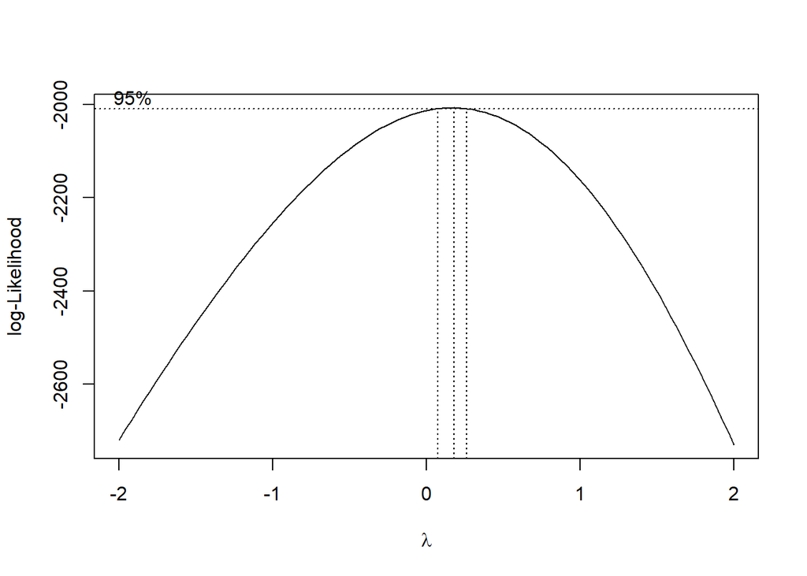

```r
# Applying Box-Cox transformation to lm object
bc.results=boxcox(DOM_Full) #Applying Box-Cox transformation to lm object
```

```r
lambda=bc.results$x[which.max(bc.results$y)] #extract the best lambda
lambda
```

```
## [1] 0.1818182
```

```r
lambda_DOM_Full <-lm(log(Future_Goals) ~ Goals + First_Assists +
                       Second_Assists + IPP + ixG + iFF + iSCF + iHDCF
                     + Rush_Attempts + Rebounds_Created + Takeaways +
                       On_The_Fly_Starts + Off_Zone_Starts +
                       Neu_Zone_Starts + Def_Zone_Starts,
                       data=train.data.DO)

# Summary
summary(lambda_DOM_Full)
```

```
##
## Call:
## lm(formula = log(Future_Goals) ~ Goals + First_Assists + Second_Assists +
##     IPP + ixG + iFF + iSCF + iHDCF + Rush_Attempts + Rebounds_Created +
##     Takeaways + On_The_Fly_Starts + Off_Zone_Starts + Neu_Zone_Starts +
##     Def_Zone_Starts, data = train.data.DO)
##
## Residuals:
##      Min       1Q   Median       3Q      Max
## -1.66518 -0.46233  0.04192  0.42288  2.12818
##
## Coefficients:
##                     Estimate Std. Error t value Pr(>|t|)
## (Intercept)        0.3913248  0.1083188   3.613 0.000324 ***
## Goals              0.0123611  0.0133773   0.924 0.355779
## First_Assists     -0.0037078  0.0106365  -0.349 0.727497
## Second_Assists    -0.0022728  0.0099856  -0.228 0.820019
## IPP                0.0008463  0.0029084   0.291 0.771138
## ixG                0.2695914  0.0729904   3.694 0.000238 ***
## iFF               -0.0002088  0.0016764  -0.125 0.900927
## iSCF               0.0031445  0.0037110   0.847 0.397088
## iHDCF             -0.0197254  0.0103013  -1.915 0.055911 .
## Rush_Attempts     -0.0115292  0.0131502  -0.877 0.380927
## Rebounds_Created  -0.0063673  0.0075633  -0.842 0.400140
## Takeaways          0.0003520  0.0029144   0.121 0.903908
## On_The_Fly_Starts -0.0003788  0.0001799  -2.105 0.035598 *
## Off_Zone_Starts    0.0005236  0.0008178   0.640 0.522185
## Neu_Zone_Starts    0.0012624  0.0007967   1.585 0.113507
## Def_Zone_Starts   -0.0003465  0.0009512  -0.364 0.715790
## ---
## Signif. codes:  0 '***' 0.001 '**' 0.01 '*' 0.05 '.' 0.1 ' ' 1
##
## Residual standard error: 0.5873 on 715 degrees of freedom
##   (1 observation deleted due to missingness)
## Multiple R-squared:  0.3389, Adjusted R-squared:  0.325
## F-statistic: 24.43 on 15 and 715 DF,  p-value: < 2.2e-16
```

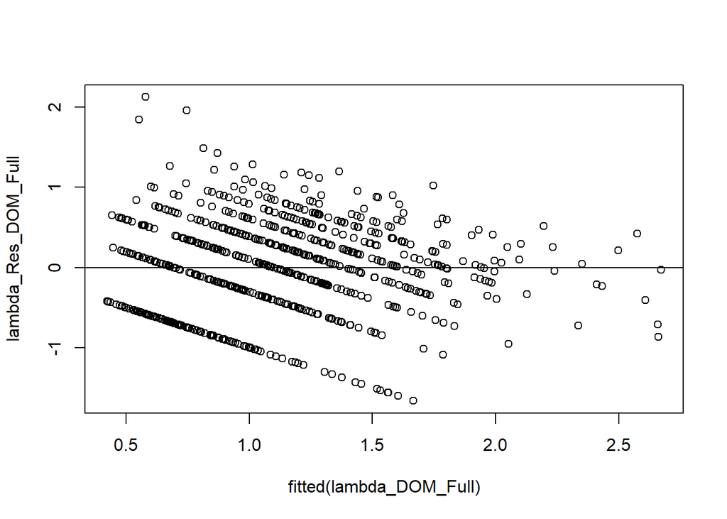

```r
# Get list of residuals
lambda_Res_DOM_Full <- resid(lambda_DOM_Full)

# Produce residual vs. fitted plot
plot(fitted(lambda_DOM_Full), lambda_Res_DOM_Full)

# Add a horizontal line at 0
abline(0,0)
```

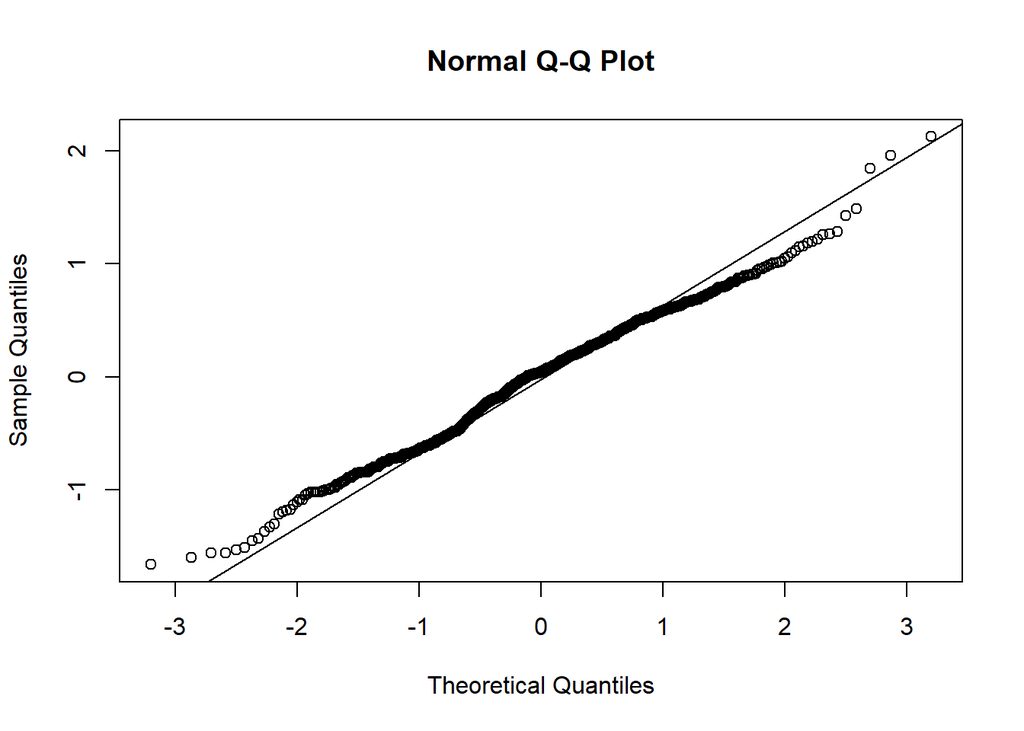

```r
# Create Q-Q plot for residuals
qqnorm(lambda_Res_DOM_Full)

# Add a straight diagonal line to the plot
qqline(lambda_Res_DOM_Full)
```

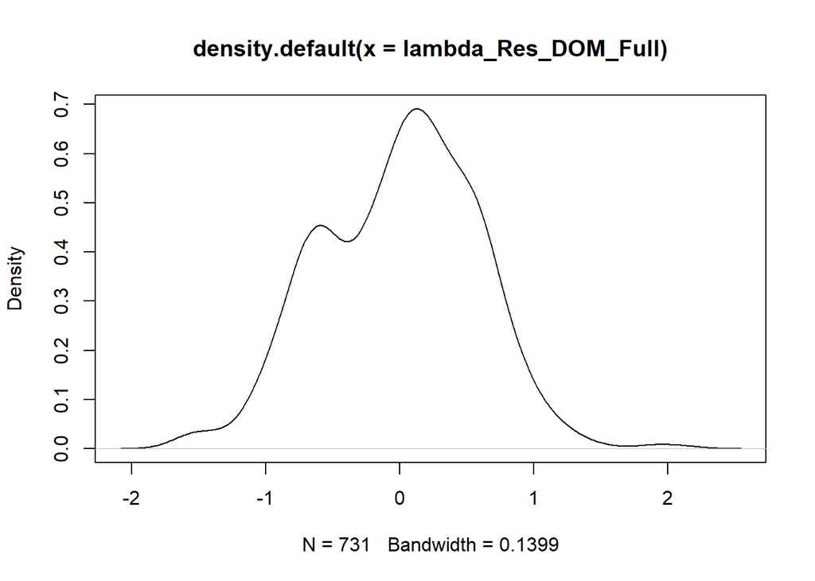

```r
# Create density plot of residuals
plot(density(lambda_Res_DOM_Full))
```

```r
# Compute VIF
vif(DOM_Full)
```

```
##             Goals     First_Assists    Second_Assists               IPP
##          2.553673          2.588017          2.383851          2.091219
##               ixG               iFF              iSCF             iHDCF
##         29.007934         16.480000         11.370624          5.192932
##     Rush_Attempts  Rebounds_Created         Takeaways On_The_Fly_Starts
##          1.784224          2.872729          2.257918          4.945156
##   Off_Zone_Starts   Neu_Zone_Starts   Def_Zone_Starts
##          5.044691         12.925617          7.852492
```

```r
# Compute VIF
vif(lambda_DOM_Full)
```

```
##             Goals     First_Assists    Second_Assists               IPP
##          2.553673          2.588017          2.383851          2.091219
##               ixG               iFF              iSCF             iHDCF
##         29.007934         16.480000         11.370624          5.192932
##     Rush_Attempts  Rebounds_Created         Takeaways On_The_Fly_Starts
##          1.784224          2.872729          2.257918          4.945156
##   Off_Zone_Starts   Neu_Zone_Starts   Def_Zone_Starts
##          5.044691         12.925617          7.852492
```

```r
# Calculate the error
accuracy(lambda_DOM_Full)
```

```
##                         ME      RMSE       MAE  MPE MAPE      MASE
## Training set -3.984825e-17 0.5808122 0.4698766 -Inf  Inf 0.7976579
```

```r
# Out-of-sample Prediction
pred_lambda_DOM_Full <- predict(lambda_DOM_Full, newdata=valid.data.DO)

# Undo the previous transformations
MSE_Lambda_DOM_Full <- 0.5873^2
Real_pred_lambda_DOM_Full <- exp(pred_lambda_DOM_Full + 1/2*MSE_Lambda_DOM_Full) - 1
Real_pred_lambda_DOM_Full
```

```
##          2          4         10         18         21         23         24
##  1.0357790  3.6638233  2.7276929  3.3751025  4.4404809  3.0044357 59.4183585
##         26         32         34         38         46         47         50
##  1.8164360  1.2625448  2.5747911  2.3821407  1.1419261  1.0666863  3.1124051
##         53         57         59         63         64         68         74
##  1.8117383  2.4210641  3.0893616 14.7676106  1.7375719  2.9480205  1.2423195
##         75         76         78         88         90         94         95
##  2.7524230  1.6039184  4.0259378  0.9558155  2.6893714  4.1747684  4.6778466
##         96         98        106        107        113        114        120
##  2.9100717  1.8234618  0.9741796  3.7806988  5.7351276  1.2417605  2.8612577
##        123        125        131        134        136        142        144
##  1.4388306  4.9051856  0.9159784  5.2542941  2.8589864  0.8910726  2.7389053
##        147        149        151        152        154        155        156
##  2.7982232  6.1445964  3.0918342  1.3736615  1.4757335  0.9542582  2.3265292
##        157        160        163        165        170        171        172
##  3.4526719  3.6532469  3.5587523  2.7474922  3.2649521  1.2460610  1.0651027
##        174        178        186        187        188        189        191
##  1.7871240  2.5298754  2.0301918  2.5439862  2.1263364  1.1610981  1.3091273
##        195        196        199        202        203        204        210
##  5.3022573  2.9723333  3.8103264  0.9172067  2.7968187  0.8982409  2.0856423
##        212        216        221        223        224        227        228
##  4.1764601  2.7798580  1.7368346  1.1059096  4.2030531  1.9962130  1.5394513
##        230        231        237        238        239        240        244
##  5.6662127  2.2459307  1.0079880  1.8948995  2.3076289  7.5035217  1.6009762
##        246        249        253        254        255        259        263
##  2.2687706  1.6391975  2.0650794  2.9436182  1.2302215  3.3668550  2.0126928
##        265        267        269        272        274        275        289
##  2.8410704  1.4341731  3.3760384  8.6784531 12.8786689  1.4135515  1.9088014
##        292        297        298        301        307        311        314
##  1.3951838  1.1362955  2.7314010  3.4932029  1.3071624  5.7180911  1.5256157
##        317        318        319        321        331        332        333
##  3.5067506  1.0150683  5.9716193  3.0722597  1.0588332  1.8348060  4.0168312
##        337        344        347        350        364        366        370
##  2.0493249  1.4483478  4.2468775  4.8402376  1.4582613  2.5374679  2.5171335
##        372        373        376        379        385        387        389
##  1.0286186  2.2591054  2.0173655  7.3441855  0.8854093  4.5449250  0.9443285
##        394        395        398        400        401        405        410
##  3.7746396  1.9386873  4.2099746  1.1634607  4.0834658  2.7086142  2.4172538
##        411        416        417        420        424        425        426
##  7.2879169  3.5990589  1.8303049  2.4565177  2.4834038  1.0636541  2.4988663
```

[output cut: 35 more lines]

```
##  2.1843685  1.4760317  2.8794650  1.1980241  2.7036769  2.0740310  4.0827365
##        880        886        888        890        895        896        897
##  2.7557332  2.7632964  1.9152606 12.8226178  1.0546947  1.8637691  2.4142618
##        900        904        907        910        915        916        923
##  3.7961239  1.8145762  1.5456080  3.0774701  3.7351154  2.7834896  3.4511657
##        926        927        928        934        937        938        940
##  2.1141286  9.1944685  4.0770033  0.7860161  3.2268204  1.3690590  1.1504851
##        942        944        947        949        951        955        956
##  3.5776681  3.2770922  0.9384724  0.9313737  3.2799632  2.1604202  2.1816600
##        957        960        963        965        970        971        978
##  6.4607917  4.8419055  2.4410443  4.3132684  1.8085038  1.9538556  5.1548396
##        986        991        998        999       1008       1013       1014
##  3.0876825  1.7281937  5.1105900  4.1712276  2.8905273  2.6984982  1.3889897
##       1026       1029       1031       1033       1038       1046       1047
##  3.8794784  1.6888563  1.9326179  2.3902113  5.1014289 13.5990920  5.6372257
```

```r
# Find the error of the validation data
accuracy(Real_pred_lambda_DOM_Full, valid.data.DO$Future_Goals)
```

```
##                 ME     RMSE     MAE      MPE    MAPE
## Test set 0.8555768 3.747724 1.97181 5.756246 48.6316
```

```r
# Best subset selection
best_subset_DOM=regsubsets(log(Future_Goals) ~ Goals + First_Assists +
                             Second_Assists + IPP + ixG + iFF + iSCF +
                             iHDCF + Rush_Attempts + Rebounds_Created +
                             Takeaways + On_The_Fly_Starts +
                             Off_Zone_Starts + Neu_Zone_Starts +
                          Def_Zone_Starts, data=train.data.DO,nvmax=15)

# Summarize the result
best_summary_DOM=summary(best_subset_DOM)
best_summary_DOM
```

```
## Subset selection object
## Call: regsubsets.formula(log(Future_Goals) ~ Goals + First_Assists +
##     Second_Assists + IPP + ixG + iFF + iSCF + iHDCF + Rush_Attempts +
##     Rebounds_Created + Takeaways + On_The_Fly_Starts + Off_Zone_Starts +
##     Neu_Zone_Starts + Def_Zone_Starts, data = train.data.DO,
##     nvmax = 15)
## 15 Variables  (and intercept)
##                   Forced in Forced out
## Goals                 FALSE      FALSE
## First_Assists         FALSE      FALSE
## Second_Assists        FALSE      FALSE
## IPP                   FALSE      FALSE
## ixG                   FALSE      FALSE
## iFF                   FALSE      FALSE
## iSCF                  FALSE      FALSE
## iHDCF                 FALSE      FALSE
## Rush_Attempts         FALSE      FALSE
## Rebounds_Created      FALSE      FALSE
## Takeaways             FALSE      FALSE
## On_The_Fly_Starts     FALSE      FALSE
## Off_Zone_Starts       FALSE      FALSE
## Neu_Zone_Starts       FALSE      FALSE
## Def_Zone_Starts       FALSE      FALSE
## 1 subsets of each size up to 15
## Selection Algorithm: exhaustive
##           Goals First_Assists Second_Assists IPP ixG iFF iSCF iHDCF
## 1  ( 1 )  " "   " "           " "            " " "*" " " " "  " "
## 2  ( 1 )  " "   " "           " "            " " "*" " " " "  "*"
## 3  ( 1 )  " "   " "           " "            " " "*" " " " "  " "
## 4  ( 1 )  " "   " "           " "            " " "*" " " " "  "*"
## 5  ( 1 )  "*"   " "           " "            " " "*" " " " "  "*"
## 6  ( 1 )  "*"   " "           " "            " " "*" " " " "  "*"
## 7  ( 1 )  "*"   " "           " "            " " "*" " " " "  "*"
## 8  ( 1 )  "*"   " "           " "            " " "*" " " "*"  "*"
## 9  ( 1 )  "*"   " "           " "            " " "*" " " "*"  "*"
## 10  ( 1 ) "*"   " "           " "            " " "*" " " "*"  "*"
## 11  ( 1 ) "*"   "*"           " "            " " "*" " " "*"  "*"
## 12  ( 1 ) "*"   "*"           " "            "*" "*" " " "*"  "*"
## 13  ( 1 ) "*"   "*"           "*"            "*" "*" " " "*"  "*"
## 14  ( 1 ) "*"   "*"           "*"            "*" "*" "*" "*"  "*"
```

[output cut: 18 more lines]

```
## 1  ( 1 )  " "             " "             " "
## 2  ( 1 )  " "             " "             " "
## 3  ( 1 )  " "             "*"             " "
## 4  ( 1 )  " "             "*"             " "
## 5  ( 1 )  " "             "*"             " "
## 6  ( 1 )  " "             "*"             " "
## 7  ( 1 )  " "             "*"             " "
## 8  ( 1 )  " "             "*"             " "
## 9  ( 1 )  "*"             "*"             " "
## 10  ( 1 ) "*"             "*"             "*"
## 11  ( 1 ) "*"             "*"             "*"
## 12  ( 1 ) "*"             "*"             "*"
## 13  ( 1 ) "*"             "*"             "*"
## 14  ( 1 ) "*"             "*"             "*"
## 15  ( 1 ) "*"             "*"             "*"
```

```r
# Find the best Cp
p=2:16
Cp=cbind(p,best_summary_DOM$cp) #Pair p and Cp
colnames(Cp)=c('p','Cp') #Define column names
print(Cp)
```

```
##        p         Cp
##  [1,]  2  5.6636396
##  [2,]  3  1.4619593
##  [3,]  4  1.1777495
##  [4,]  5 -1.7818756
##  [5,]  6 -0.8800371
##  [6,]  7  0.1940418
##  [7,]  8  1.5216595
##  [8,]  9  2.7570294
##  [9,] 10  4.3117775
## [10,] 11  6.1772904
## [11,] 12  8.1151660
## [12,] 13 10.0707741
## [13,] 14 12.0287947
## [14,] 15 14.0145852
## [15,] 16 16.0000000
```

```r
# Find BIC
p=2:16
BIC=cbind(p,best_summary_DOM$bic) #Pair p and BIC
colnames(BIC)=c('p','BIC') #Define column names
print(BIC)
```

```
##        p       BIC
##  [1,]  2 -271.4606
##  [2,]  3 -271.0801
##  [3,]  4 -266.7878
##  [4,]  5 -265.2170
##  [5,]  6 -259.7396
##  [6,]  7 -254.0883
##  [7,]  8 -248.1795
##  [8,]  9 -242.3656
##  [9,] 10 -236.2261
## [10,] 11 -229.7691
## [11,] 12 -223.2382
## [12,] 13 -216.6891
## [13,] 14 -210.1376
## [14,] 15 -203.5578
## [15,] 16 -196.9783
```

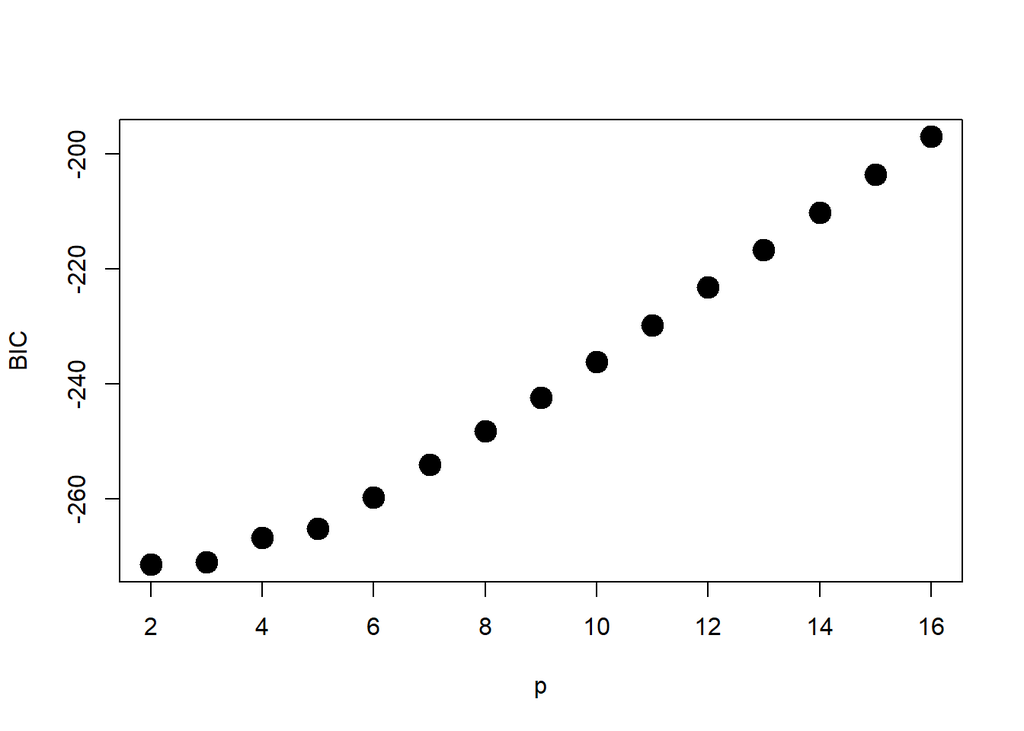

```r
plot(BIC,cex=2,pch=19) # Plot of BIC
```

```r
# Find AIC
n=nrow(train.data.DO)
p=BIC[,1]
aic=BIC[,2]-p*log(n)+2*p #Need to compute AIC using BIC
AIC=cbind(2:16,aic) #Pair p and AIC
colnames(AIC)=c('p','AIC') #Define column names
print(AIC)
```

```
##        p       AIC
##  [1,]  2 -280.6522
##  [2,]  3 -284.8675
##  [3,]  4 -285.1709
##  [4,]  5 -288.1959
##  [5,]  6 -287.3142
##  [6,]  7 -286.2587
##  [7,]  8 -284.9458
##  [8,]  9 -283.7276
##  [9,] 10 -282.1839
## [10,] 11 -280.3227
## [11,] 12 -278.3875
## [12,] 13 -276.4343
## [13,] 14 -274.4786
## [14,] 15 -272.4945
## [15,] 16 -270.5107
```

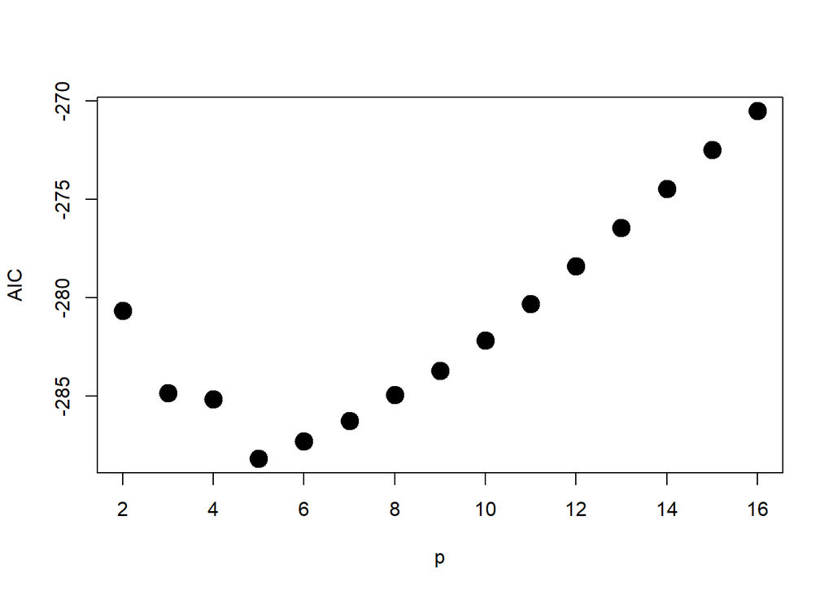

```r
plot(AIC,cex=2,pch=19) #Plot of AIC
```